# Analysis 1 — Hit prediction

crystal_full_test_contig (n=128, 38 hits)

Published

May 24, 2026

## 1 Background

A hit is defined as a design with cross_tier ∈ {A, B, C} — a negsteer outcome where the binder discriminates between the true receptor and the scrambled negative control.

This analysis asks what features predict hit outcome. The features are split into two groups with different practical implications:

**Pre-Boltz features** (Rosetta backbone geometry + MPNN sequence properties) are available before the expensive Boltz-2 prediction step. If these predict hits, designs could in principle be filtered upstream to save compute.

**Post-Boltz features** (Boltz-2 structural confidence and contact metrics) are co-measured with the outcome in the same Boltz run. They cannot be used for pre-screening, but they describe which aspects of the Boltz prediction quality characterise successful designs — a mechanistic picture of what separates hits from non-hits.

The two groups are modelled separately. Mixing them in a single model would cause the Boltz features to dominate and obscure any pre-Boltz signal.

Features excluded and why are documented in `00_glossary.qmd`.

## 2 Setup

```python
import sys
sys.path.insert(0, ".")
from helpers import (
    load_run, RUNS, OUT_DIR, SEED,
    backbone_cv, fit_and_shap, lgbm_classifier,
    beeswarm, dependence, top_features,
    STAGE_COLOURS,
)
import pandas as pd
import numpy as np
import matplotlib.pyplot as plt
from IPython.display import display

df = load_run("crystal", RUNS["crystal"])

print(f"n = {len(df)} designs  |  hits = {df['hit'].sum()} ({df['hit'].mean()*100:.1f}%)")
print(f"Backbone groups (design_idx): {df['design_idx'].nunique()}")
```

```
n = 128 designs  |  hits = 38 (29.7%)
Backbone groups (design_idx): 64
```

### 2.1 Feature sets

```python
FEATS_PRE_BOLTZ = [
    # Rosetta / backbone stage
    "sc_value",           # shape complementarity
    "dSASA_int",          # buried interface area
    "delta_unsatHbonds",  # unsatisfied H-bonds (tentative: Rosetta rotamers)
    "loop1_len",          # RFDiffusion loop length choice
    # MPNN / sequence stage
    "mpnn_score",
    "design_region_score",
    "loop_hydrophob_frac",
    "loop_net_charge",
    "loop_has_proline",
]

FEATS_POST_BOLTZ = [
    "rep_iptm_median",
    "rep_interface_plddt_median",
    "rep_independent_receptor_rmsd_median",
    "rep_independent_effector_rmsd_median",
    "rep_n_contact_residues_median",
]

stage_legend = pd.DataFrame([
    {"Group": "Pre-Boltz — Rosetta",  "Colour": "red",   "Features": "sc_value, dSASA_int, delta_unsatHbonds, loop1_len"},
    {"Group": "Pre-Boltz — MPNN",     "Colour": "blue",  "Features": "mpnn_score, design_region_score, loop_hydrophob_frac, loop_net_charge, loop_has_proline"},
    {"Group": "Post-Boltz — Boltz",   "Colour": "green", "Features": "rep_iptm_median, rep_interface_plddt_median, rep_independent_receptor_rmsd_median, rep_independent_effector_rmsd_median, rep_n_contact_residues_median"},
])
display(stage_legend.style.hide(axis="index"))
```

[output not shown]

## 3 Part A — Pre-Boltz prediction

### 3.1 Hypotheses

**H0:** No backbone geometry or sequence feature measured before Boltz is run predicts hit outcome. Hit probability is uniform across the space of designs that pass the sc ≥ 0.3 Rosetta filter.

*Rationale:* The design pipeline applies a coarse quality filter at the Rosetta stage, but the 64 passing backbones may be broadly equivalent in hit potential. Similarly, MPNN sequence probability may be unrelated to the specificity that negsteer rewards.

**H1:** One or more upstream features predict hit outcome, meaning designs could be filtered before running the expensive Boltz step.

*Rationale:* RFDiffusion’s loop length choice constrains the backbone geometry in ways that may favour or disfavour correct effector placement. Sequence composition (charge, proline, hydrophobicity) may influence how Boltz folds the complex and therefore which designs produce high-confidence interface predictions.

### 3.2 Model

LightGBM binary classifier. Cross-validation uses `GroupShuffleSplit` by backbone (`design_idx`) so sibling sequences from the same backbone always land in the same fold, preventing leakage between the two MPNN samples per backbone.

```python
groups = df["design_idx"]
X_pre  = df[FEATS_PRE_BOLTZ].apply(pd.to_numeric, errors="coerce").fillna(
         df[FEATS_PRE_BOLTZ].apply(pd.to_numeric, errors="coerce").median())
y      = df["hit"]

model_pre = lgbm_classifier()
auc_mean, auc_std = backbone_cv(model_pre, X_pre, y, groups, "roc_auc")
print(f"Pre-Boltz CV AUC = {auc_mean:.3f} ± {auc_std:.3f}")
```

```
Pre-Boltz CV AUC = 0.528 ± 0.195
```

### 3.3 Results

#### 3.3.1 Cross-validated AUC

A CV AUC near 0.5 means the pre-Boltz features carry no predictive signal — the model performs at chance on held-out backbones. An AUC substantially above 0.5 would indicate that designs could be filtered before running Boltz.

#### 3.3.2 SHAP beeswarm

Even when overall AUC is near chance, the beeswarm reveals which features the model weighted most heavily. When AUC is near 0.5 these should be interpreted with caution — the model may be fitting noise. Look for features where the SHAP value direction is consistent (all red dots on one side, all blue on the other) as a sign of a genuine signal rather than noise.

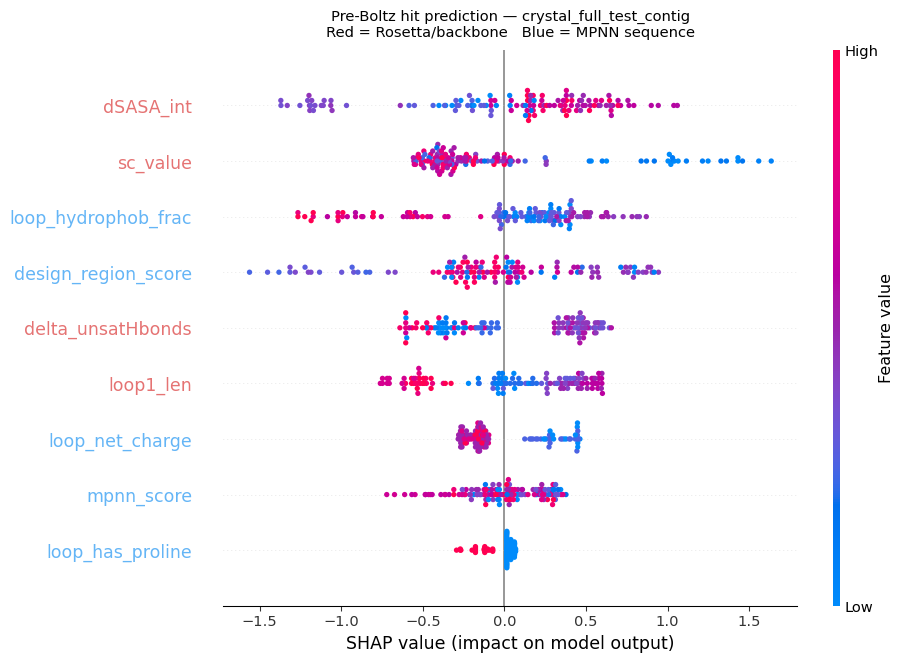

```python
_, sv_pre = fit_and_shap(lgbm_classifier(), X_pre, y)
beeswarm(
    sv_pre, X_pre,
    title="Pre-Boltz hit prediction — crystal_full_test_contig\n"
          "Red = Rosetta/backbone   Blue = MPNN sequence",
    save_name="a1_pre_boltz_beeswarm",
)
```

#### 3.3.3 Dependence plots — top 3 features

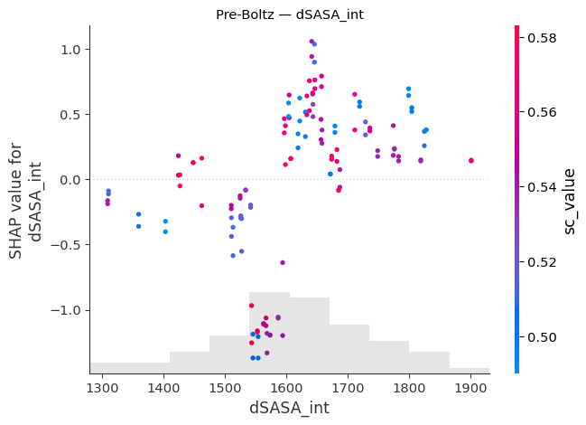

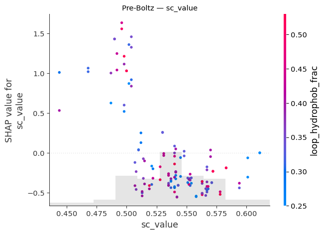

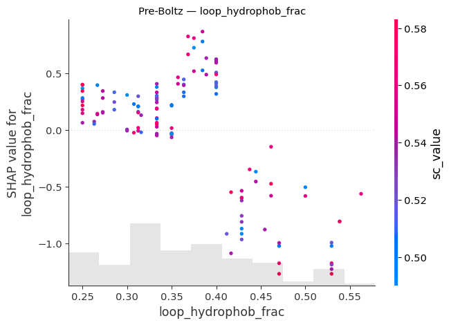

```python
top3_pre = top_features(sv_pre, list(X_pre.columns), n=3)
for i, feat in enumerate(top3_pre):
    colour_by = top3_pre[1] if feat != top3_pre[1] else top3_pre[2]
    dependence(
        sv_pre, X_pre, feat, colour_by,
        title=f"Pre-Boltz — {feat}",
        save_name=f"a1_pre_boltz_dep_{i+1}_{feat}",
    )
```

## 4 Part B — Post-Boltz prediction

### 4.1 Hypotheses

**H0:** No Boltz-2 structural quality metric is systematically associated with hit outcome. Designs that pass the Rosetta filter are equally likely to be hits regardless of their Boltz prediction confidence.

*Rationale:* If Boltz places the effector at the correct interface in all cases, then confidence metrics would not discriminate between hits and non-hits — the outcome would depend only on the sequence specificity, not the prediction quality.

**H1:** Specific Boltz-2 quality metrics characterise hits, identifying which aspects of the structural prediction determine success.

*Rationale:* Based on the within-backbone sibling analysis, interface pLDDT and receptor RMSD both strongly discriminate which sibling hits (88% and 81% accuracy respectively). These metrics reflect whether Boltz predicts a geometrically coherent, well-defined interface — and that geometric coherence may be the primary gate between a correctly-placed effector and a confirmed hit.

Note: these features are co-measured with the outcome in the same Boltz run. This analysis is mechanistic — it describes what a hit looks like in Boltz prediction space — not a prediction of hits before Boltz is run.

### 4.2 Model

```python
X_post = df[FEATS_POST_BOLTZ].apply(pd.to_numeric, errors="coerce").fillna(
         df[FEATS_POST_BOLTZ].apply(pd.to_numeric, errors="coerce").median())

model_post = lgbm_classifier()
auc_mean_post, auc_std_post = backbone_cv(model_post, X_post, y, groups, "roc_auc")
print(f"Post-Boltz CV AUC = {auc_mean_post:.3f} ± {auc_std_post:.3f}")
```

```
Post-Boltz CV AUC = 0.869 ± 0.096
```

### 4.3 Results

#### 4.3.1 Cross-validated AUC

The AUC here is expected to be higher than Part A. The key questions are (1) how high, and (2) whether a model trained only on Boltz quality metrics generalises across backbones — i.e. whether the same Boltz signatures predict hits on backbones it has not seen.

#### 4.3.2 SHAP beeswarm

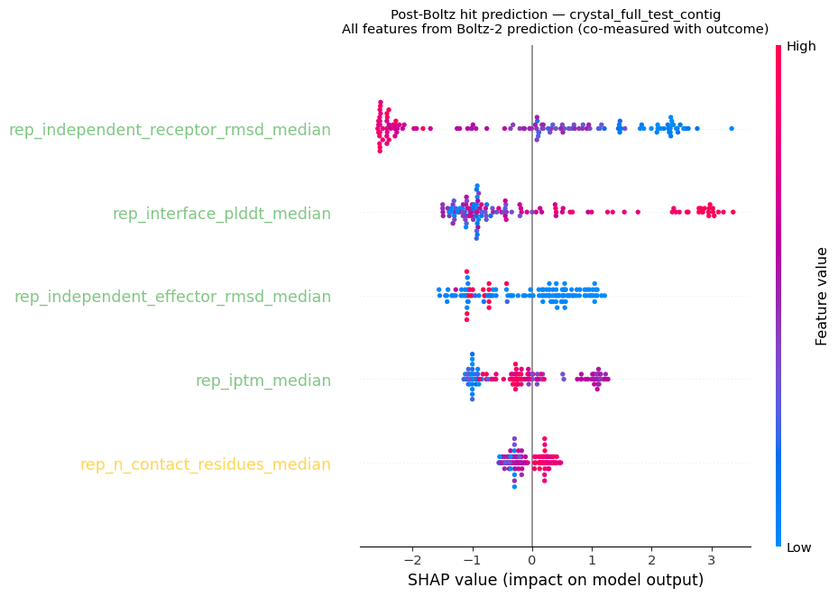

```python
_, sv_post = fit_and_shap(lgbm_classifier(), X_post, y)
beeswarm(
    sv_post, X_post,
    title="Post-Boltz hit prediction — crystal_full_test_contig\n"
          "All features from Boltz-2 prediction (co-measured with outcome)",
    save_name="a1_post_boltz_beeswarm",
)
```

#### 4.3.3 Dependence plots — top 3 features

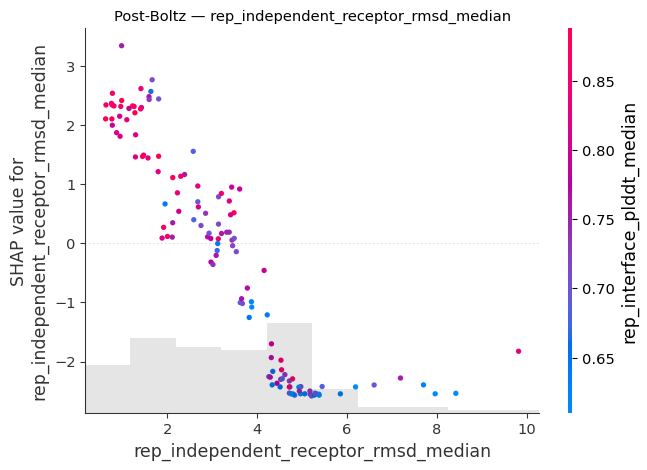

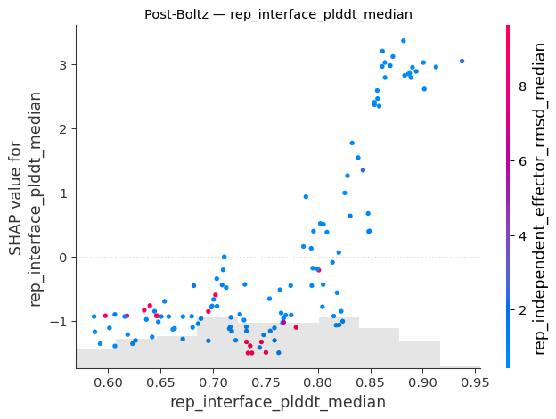

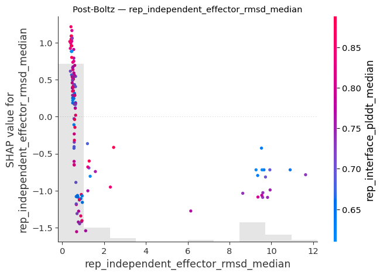

```python
top3_post = top_features(sv_post, list(X_post.columns), n=3)
for i, feat in enumerate(top3_post):
    colour_by = top3_post[1] if feat != top3_post[1] else top3_post[2]
    dependence(
        sv_post, X_post, feat, colour_by,
        title=f"Post-Boltz — {feat}",
        save_name=f"a1_post_boltz_dep_{i+1}_{feat}",
    )
```

### 4.4 Interpretation

> *Questions to address:*
> - *Which Boltz metric ranks highest? The sibling analysis found interface* *pLDDT was the strongest discriminator (88%), with receptor RMSD second* *(81%). Does the population-level SHAP agree?*
> - *For `rep_independent_receptor_rmsd_median`: in the dependence plot,* *is there a clear threshold above which SHAP becomes strongly negative* *(predicting non-hit)? A threshold would suggest a natural filter cutoff.*
> - *`rep_n_contact_residues_median` measures the total number of receptor* *residues contacted. Is more contact always better, or is there a plateau* *or reversal at very high contact counts (over-packing)?*
> - *`rep_independent_effector_rmsd_median` measures whether the binder itself* *folds differently in complex vs alone. A high SHAP contribution here* *would suggest the binder’s own fold quality matters as much as the* *receptor’s — which would be unexpected given that the binder sequence* *is being specifically designed for this backbone.*
> - *The CV AUC tells you how well these Boltz metrics generalise across* *different backbones. If high (> 0.85), the same quality thresholds* *apply across all 64 backbone designs. If moderate (0.65–0.85), the* *relationship between Boltz quality and hits is backbone-dependent.*